# Prosper: Fintech and new Lending Models

Prosper is a online marketplace lending that connects borrowers and investor and matches individuals who wish to obtain unsecured consumer loans (“borrowers”) with those who are willing to help fund those loans (“investors”). A borrower who wishes to obtain a loan through marketplace must post a loan listing to marketplace. If a listing receives enough investor commitments to be funded. Due to the novel nature of the peer-to-peer lending models, the SEC, on November 24, 2008, imposed a cease and desist order on Prosper. After review,the SEC treats all peer-to-peer lending transactions as sales of securities and requires that all platforms register with the SEC, and Prosper, in July 2009, reopened their website for lending (“investing”) and borrowing. Prosper provides information about loan. This report explores “Loan Data from Prosper” data set. In particular, the loan issues after SEC registration.

```
## 'data.frame':    113937 obs. of  81 variables:
##  $ ListingKey                         : Factor w/ 113066 levels "00003546482094282EF90E5",..: 7180 7193 6647 6669 6686 6689 6699 6706 6687 6687 ...
##  $ ListingNumber                      : int  193129 1209647 81716 658116 909464 1074836 750899 768193 1023355 1023355 ...
##  $ ListingCreationDate                : Factor w/ 113064 levels "2005-11-09 20:44:28.847000000",..: 14184 111894 6429 64760 85967 100310 72556 74019 97834 97834 ...
##  $ CreditGrade                        : Factor w/ 9 levels "","A","AA","B",..: 5 1 8 1 1 1 1 1 1 1 ...
##  $ Term                               : int  36 36 36 36 36 60 36 36 36 36 ...
##  $ LoanStatus                         : Factor w/ 12 levels "Cancelled","Chargedoff",..: 3 4 3 4 4 4 4 4 4 4 ...
##  $ ClosedDate                         : Factor w/ 2803 levels "","2005-11-25 00:00:00",..: 1138 1 1263 1 1 1 1 1 1 1 ...
##  $ BorrowerAPR                        : num  0.165 0.12 0.283 0.125 0.246 ...
##  $ BorrowerRate                       : num  0.158 0.092 0.275 0.0974 0.2085 ...
##  $ LenderYield                        : num  0.138 0.082 0.24 0.0874 0.1985 ...
##  $ EstimatedEffectiveYield            : num  NA 0.0796 NA 0.0849 0.1832 ...
##  $ EstimatedLoss                      : num  NA 0.0249 NA 0.0249 0.0925 ...
##  $ EstimatedReturn                    : num  NA 0.0547 NA 0.06 0.0907 ...
##  $ ProsperRating..numeric.            : int  NA 6 NA 6 3 5 2 4 7 7 ...
```

[output cut: 67 more lines]

```r
# Convert 'LoanOriginationDate' variable in an object of type 'character' and
# then in an objects of class 'Date'
df$LoanOriginationDate <- as.Date(as.character(df$LoanOriginationDate), format = "%Y-%m-%d")

# Filter the data of 'df' data frame object which meet a particular condition
df <- subset(df, LoanOriginationDate >= as.Date("2009-07-13"))
df <- subset(df, TotalProsperLoans == 0 | is.na(TotalProsperLoans))
df <- subset(df, LoanStatus != "Current")
df <- subset(df, Term != 12)
df <- subset(df, ProsperRating..Alpha. != "")
df <- subset(df, !is.na(DebtToIncomeRatio))
```

# Univariate Plots Section

Prosper provides information to investors in order to help them make sound investment decisions.The historical performance of Borrower Loans are incorporate into proprietary rating system. Each listing is assigned a Prosper Rating. The rating associated with a listing reflects the loss expectations for that listing as of the time the rating is given.

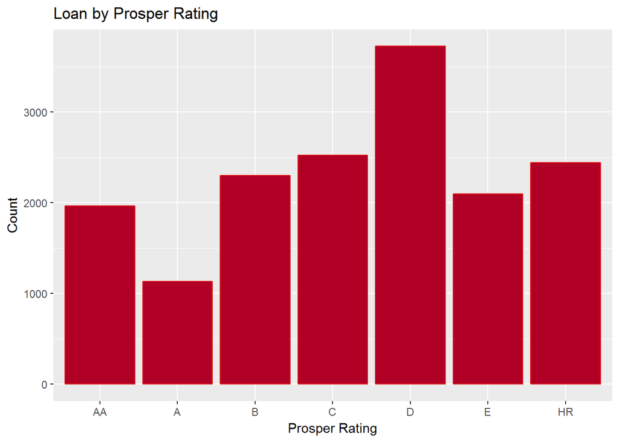

There are seven Prosper Rating, It goes as follows, from excellent to poor: AA, A, B, C, D, E, HR.We can observe, in the chart above, number of loans are assigned a Prosper Rating. The ‘ProsperRating..Alpha.’ variable is important, in fact the maximum loan amount and interest rates are determined by the borrower’s Prosper Rating. Prosper Marketplace offers unsecured consumer loans from 2,000 dollars to 35,000 dollars.

```r
summary(df$LoanOriginalAmount)
```

```
##    Min. 1st Qu.  Median    Mean 3rd Qu.    Max.
##    1000    3500    5000    6950   10000   35000
```

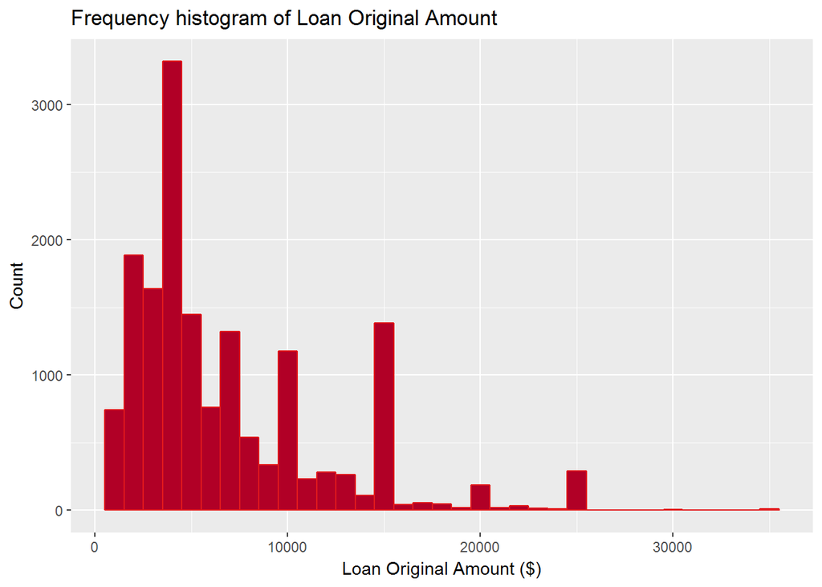

It is confirmed that Prosper marketplace offers $35,000 as maximum amount of the loans. Over the time, the minimum amount is increased. In the Prosper Prospectus, we find a table that shows the maximum loan amount for each Prosper Rating. We compare this table with data of database that we are using in the analysis.

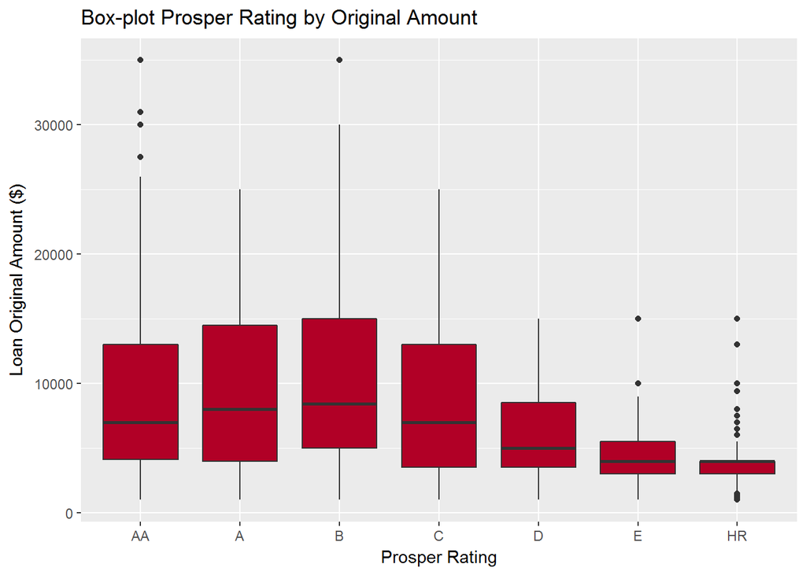

The box-plot shows, as we expected, that the amount of the loan with the worst rating classes is less than the best rating classes. Based on the information in the Prospectus, over the time, the amount for the worst classes is reduced. Prosper offers fixed rate, fully amortizing.

```r
summary(df$BorrowerRate)
```

```
##    Min. 1st Qu.  Median    Mean 3rd Qu.    Max.
##  0.0423  0.1559  0.2468  0.2249  0.2962  0.3600
```

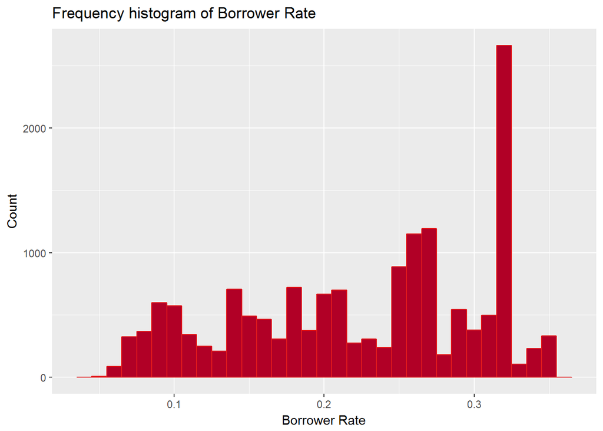

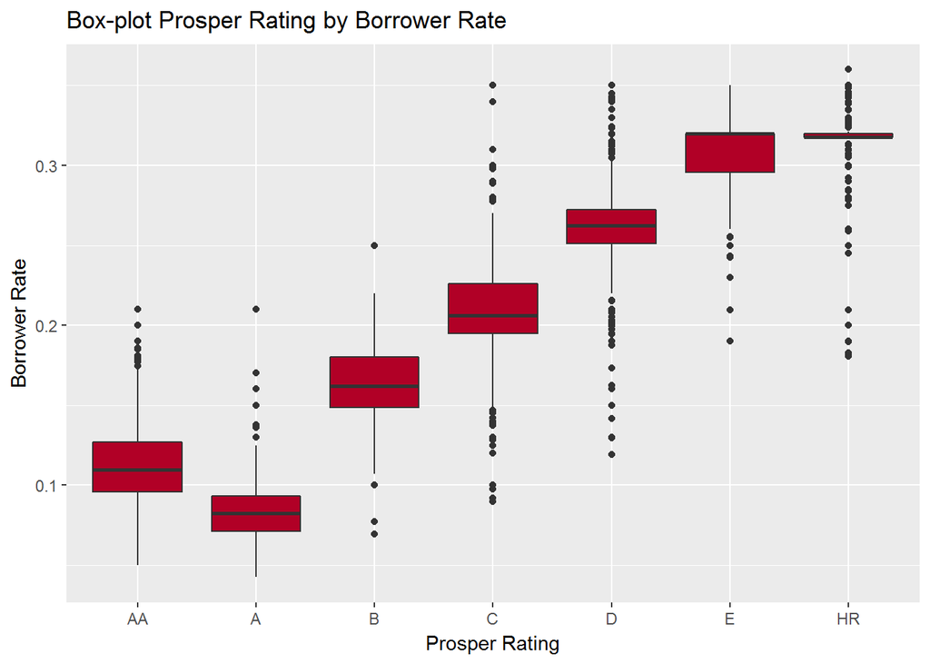

The box-plot displays the full range of variation of Borrower Rate for each Prosper Rating, the figure don’t confirm ranges given in the Prospectus, given that over time have been updated. The Borrower Rate depends on Prosper Rating. It is determined principal based on two scores: a custom Prosper Score,‘ProsperScore’, and a credit score obtained from a credit reporting agency, ‘CreditScoreRangeLower’,‘CreditScoreRangeUpper’.

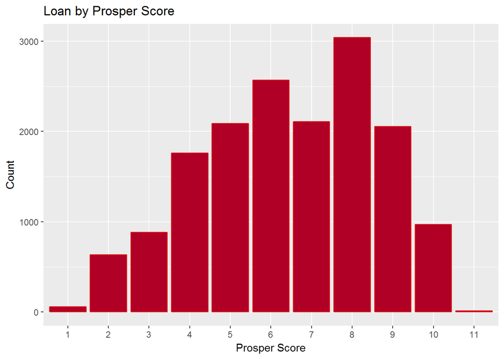

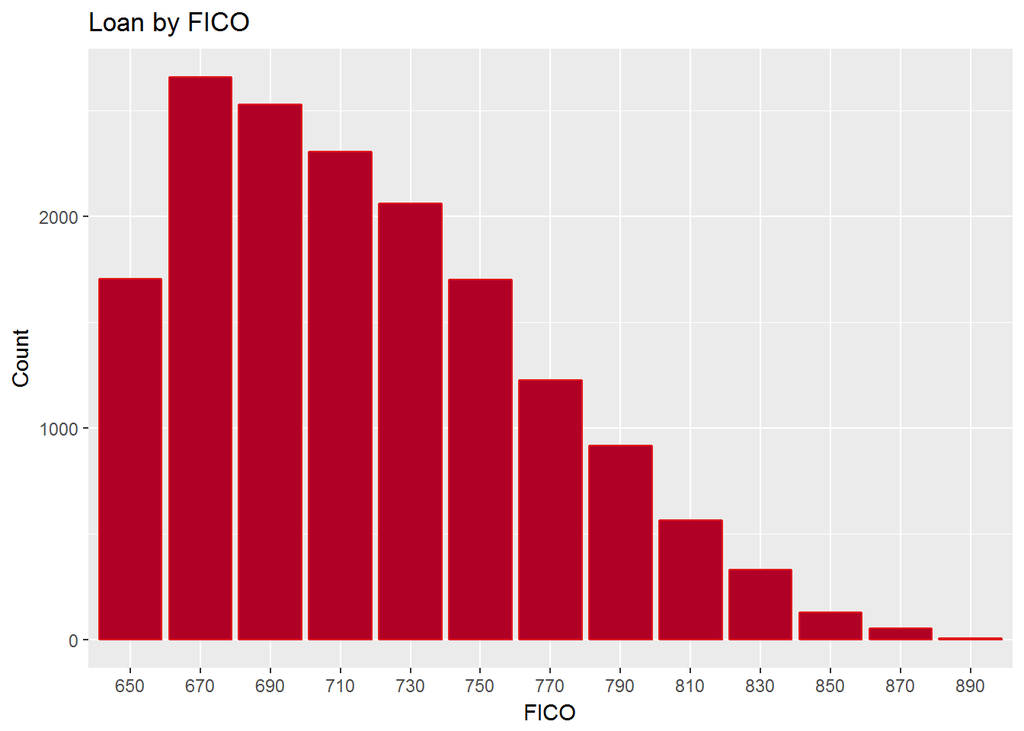

In the above graphs, we show Rating tiers for Prosper Score and FICO. The Prosper Score predicts the probability of a Borrower Loan going “bad”. In the Prosper Prospectus, “bad” is defined as going more than 60 days past due within twelve months of the application date.

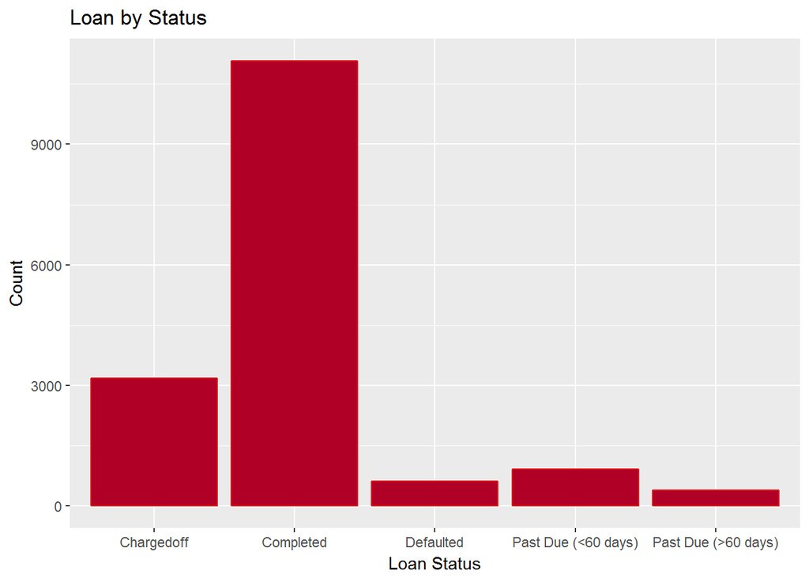

In the figures above, we show the Credit Lending Model of Prosper able to discriminate “Bad” loan. Many loans are not in default. The defaults and in situation of near default are physiological in the lending activities. We investigate some variable in the dataset that it can impact on the probability of default.

A line of credit is an arrangement between a financial institution and a customer that establishes a maximum loan balance that the lender permits the borrower to access or maintain. The borrower can access funds from the line of credit at any time, as long as he does not exceed the maximum amount set in the agreement and as long as he meets any other requirements set by the financial institution.  
The ‘CurrentCreditLines’ variable, the number of open or closed accounts in the borrower’s name that the borrower is paying on time.

```r
summary(df$CurrentCreditLines)
```

```
##    Min. 1st Qu.  Median    Mean 3rd Qu.    Max.
##   0.000   6.000   9.000   9.358  12.000  40.000
```

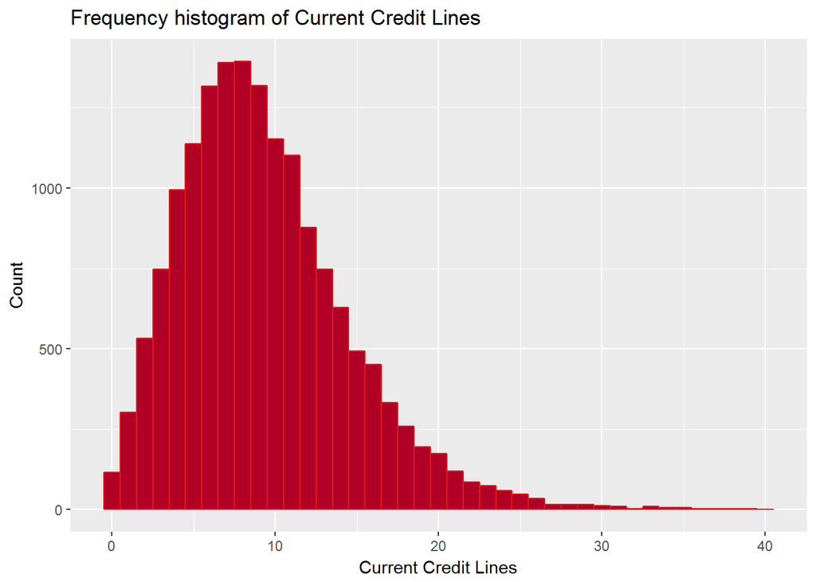

The ‘OpenCreditLines’ variable, the total number of open accounts.

```r
summary(df$OpenCreditLines)
```

```
##    Min. 1st Qu.  Median    Mean 3rd Qu.    Max.
##   0.000   5.000   8.000   8.304  11.000  37.000
```

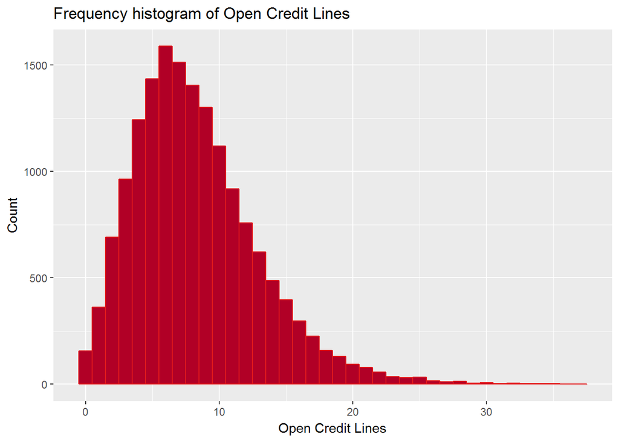

The ‘TotalCreditLinespast7years’ variable, the total number of credit lines appearing on the borrower’s credit report in the past 7 years.

```r
summary(df$TotalCreditLinespast7years)
```

```
##    Min. 1st Qu.  Median    Mean 3rd Qu.    Max.
##    2.00   16.00   24.00   26.14   34.00  124.00
```

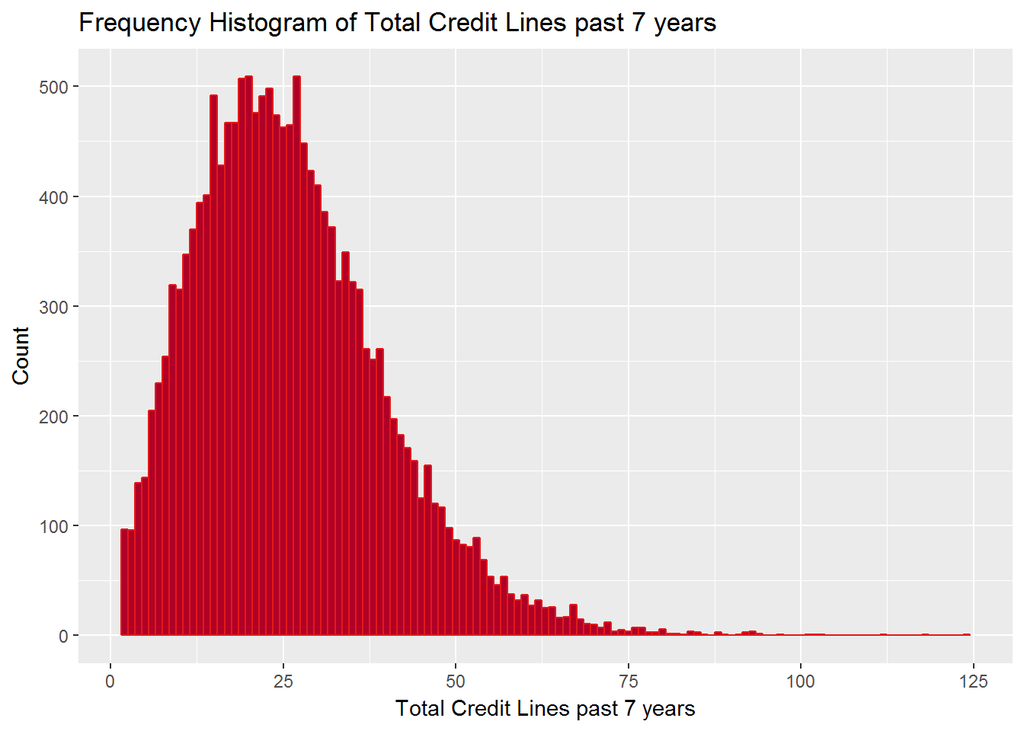

Revolving Account is a type of credit account in which the customer may defer payment on part of the balance. Interest is charged on the unpaid balance and added to the total owed.

```r
summary(df$OpenRevolvingAccounts)
```

```
##    Min. 1st Qu.  Median    Mean 3rd Qu.    Max.
##   0.000   3.000   6.000   6.445   9.000  35.000
```

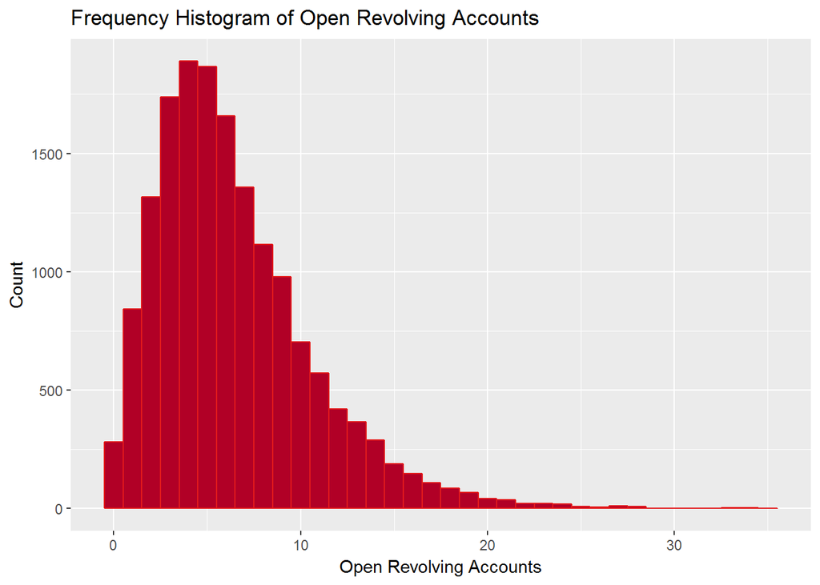

The ‘OpenRevolvingMonthlyPayment’ variable, it’s the minimum requires we pay each month to keep your account in good standing.

```r
summary(df$OpenRevolvingMonthlyPayment)
```

```
##    Min. 1st Qu.  Median    Mean 3rd Qu.    Max.
##     0.0    99.0   241.0   357.9   474.0  5155.0
```

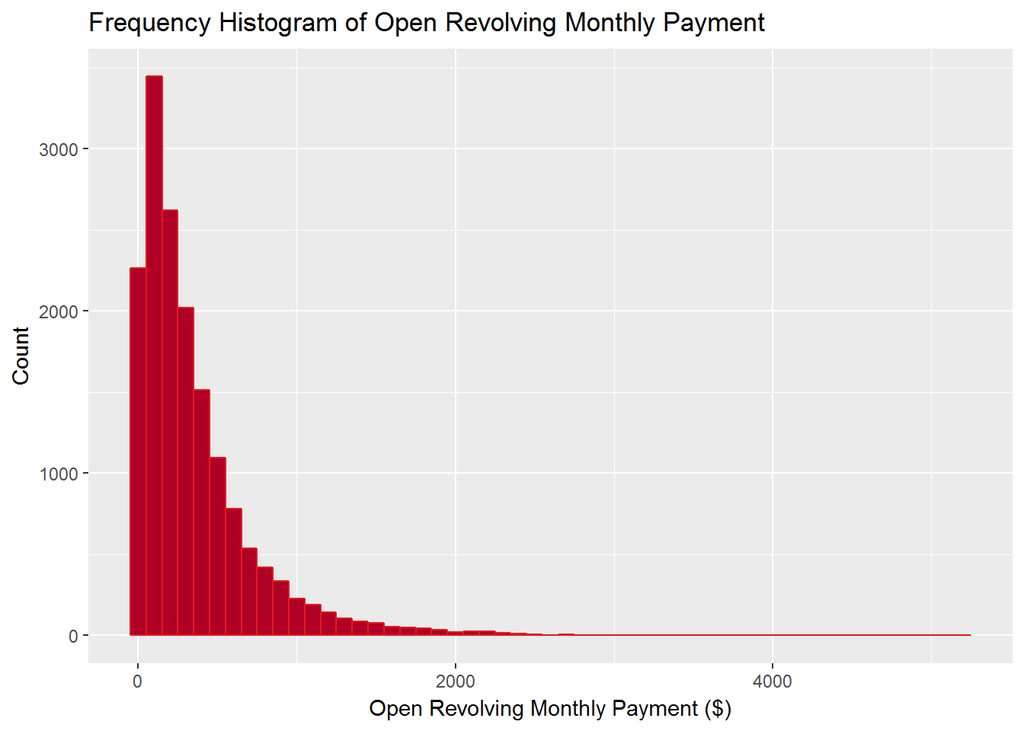

The ‘InquiriesLast6Months’ variable and ‘TotalInquiries’ variable, the number of times a bank or other business has requested the borrower’s credit profile from a consumer credit rating agency, respectively last 6 Months and borrower’s credit history.

```r
summary(df$InquiriesLast6Months)
```

```
##    Min. 1st Qu.  Median    Mean 3rd Qu.    Max.
##   0.000   0.000   1.000   1.166   2.000  20.000
```

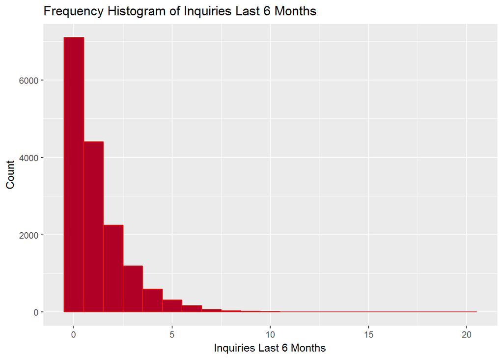

```r
summary(df$TotalInquiries)
```

```
##    Min. 1st Qu.  Median    Mean 3rd Qu.    Max.
##   0.000   2.000   3.000   4.285   6.000  51.000
```

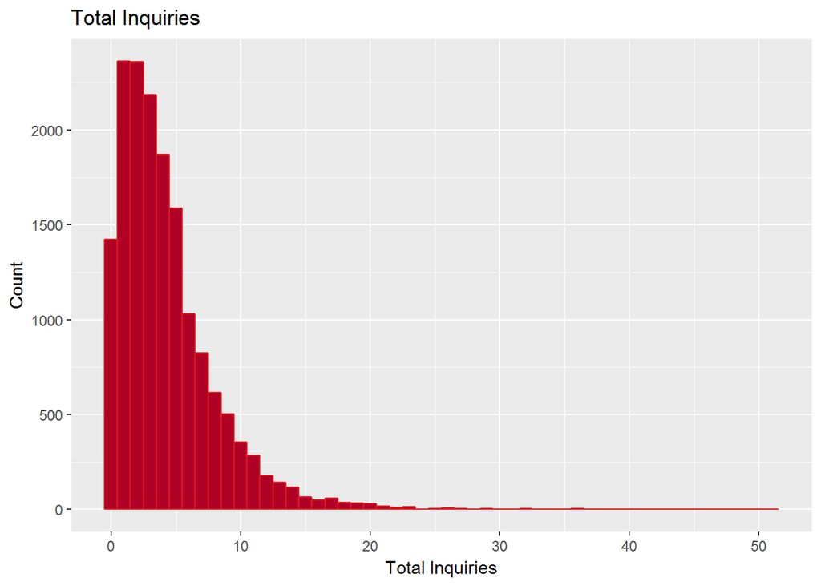

The ‘CurrentDelinquencies’ variable and ‘DelinquenciesLast7Years’, the number of times the borrower has been more than 90 days late with a payment, respectively actually and last 7 Years.

```r
summary(df$CurrentDelinquencies)
```

```
##    Min. 1st Qu.  Median    Mean 3rd Qu.    Max.
##  0.0000  0.0000  0.0000  0.3486  0.0000 32.0000
```

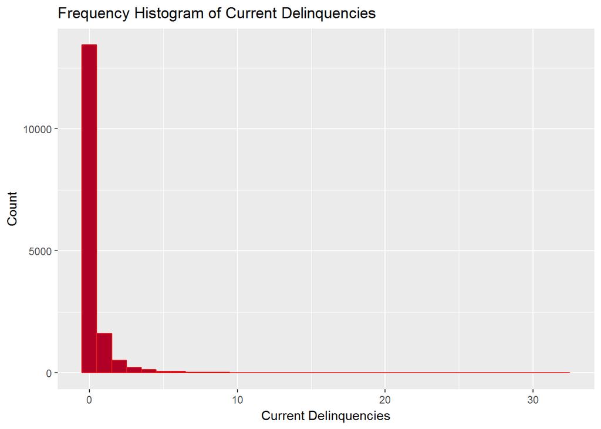

```r
summary(df$DelinquenciesLast7Years)
```

```
##    Min. 1st Qu.  Median    Mean 3rd Qu.    Max.
##   0.000   0.000   0.000   3.546   2.000  99.000
```

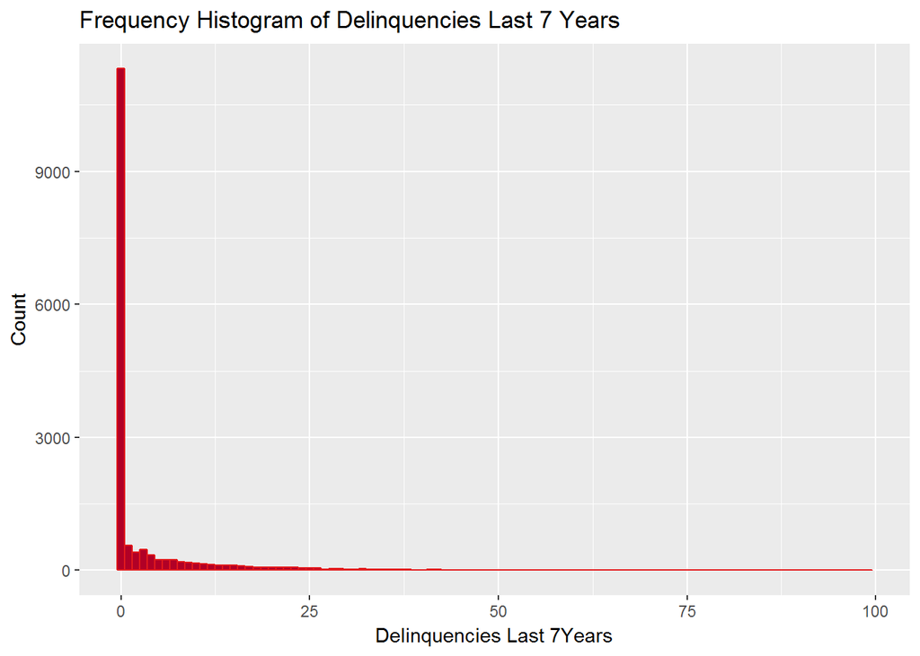

The “AmountDelinquent” variable, indicates the past due amounts owed by the borrower.

```r
summary(df$AmountDelinquent)
```

```
##     Min.  1st Qu.   Median     Mean  3rd Qu.     Max.
##      0.0      0.0      0.0    962.8      0.0 327700.0
```

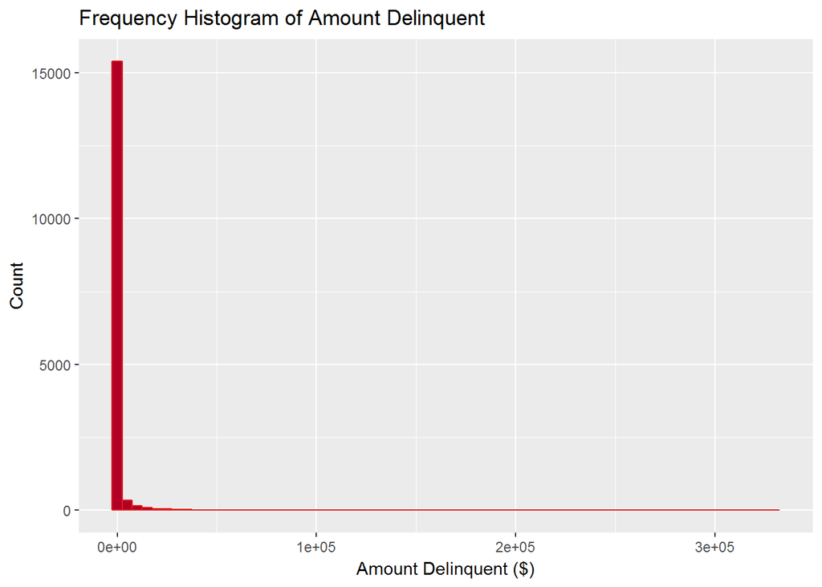

The ‘PublicRecordsLast10Years’ variable and ‘PublicRecordsLast12Months’ variable, the number of public records on the borrower’s credit report, respectively last 10 years and lasr 12 Months.

```r
summary(df$PublicRecordsLast10Years)
```

```
##    Min. 1st Qu.  Median    Mean 3rd Qu.    Max.
##  0.0000  0.0000  0.0000  0.2622  0.0000 11.0000
```

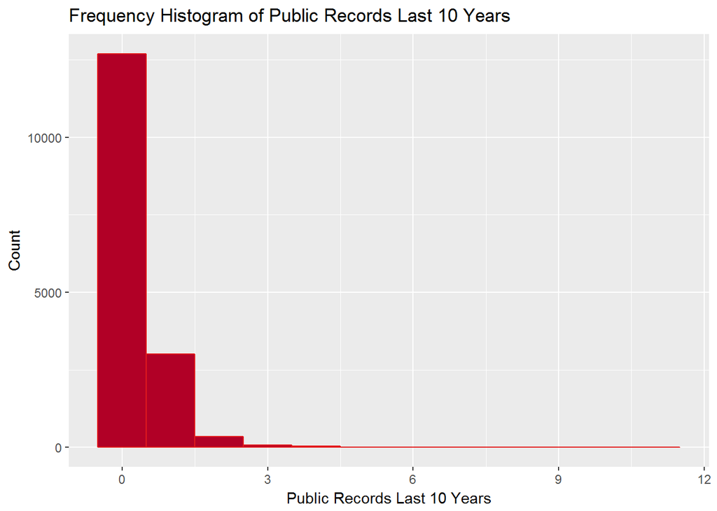

```r
summary(df$PublicRecordsLast12Months)
```

```
##    Min. 1st Qu.  Median    Mean 3rd Qu.    Max.
## 0.00000 0.00000 0.00000 0.01137 0.00000 3.00000
```

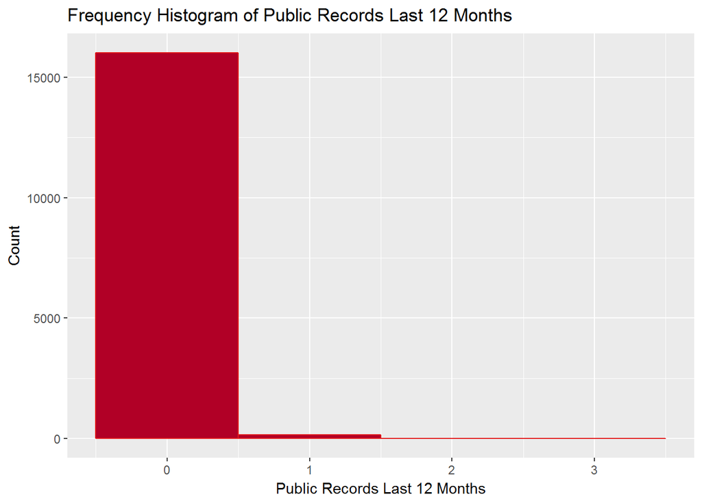

The ‘RevolvingCreditBalance’ variable, the total outstanding balance that the borrower owes on open credit cards or other revolving credit accounts.

```r
summary(df$RevolvingCreditBalance)
```

```
##    Min. 1st Qu.  Median    Mean 3rd Qu.    Max.
##       0    2075    7047   15590   17170  879800
```

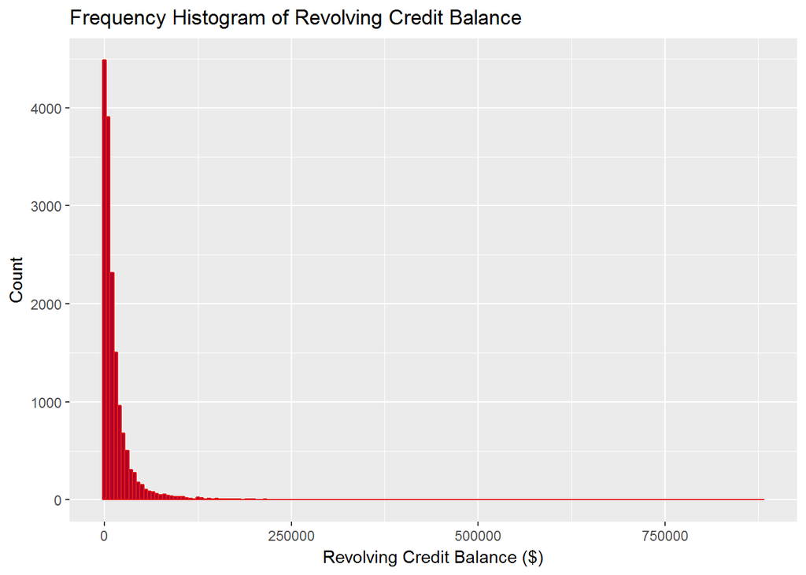

The ‘BankcardUtilization’ variable, the sum of the balances owed on open bankcards divided by the sum of the cards’ credit limits.

```r
summary(df$BankcardUtilization)
```

```
##    Min. 1st Qu.  Median    Mean 3rd Qu.    Max.
##  0.0000  0.2300  0.5400  0.5134  0.8000  2.2300
```

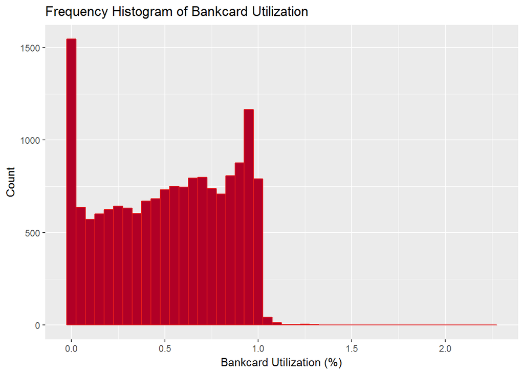

The ‘AvailableBankcardCredit’ variable, the total available credit via bank card.

```r
summary(df$AvailableBankcardCredit)
```

```
##    Min. 1st Qu.  Median    Mean 3rd Qu.    Max.
##       0     886    4223   10710   13130  498400
```

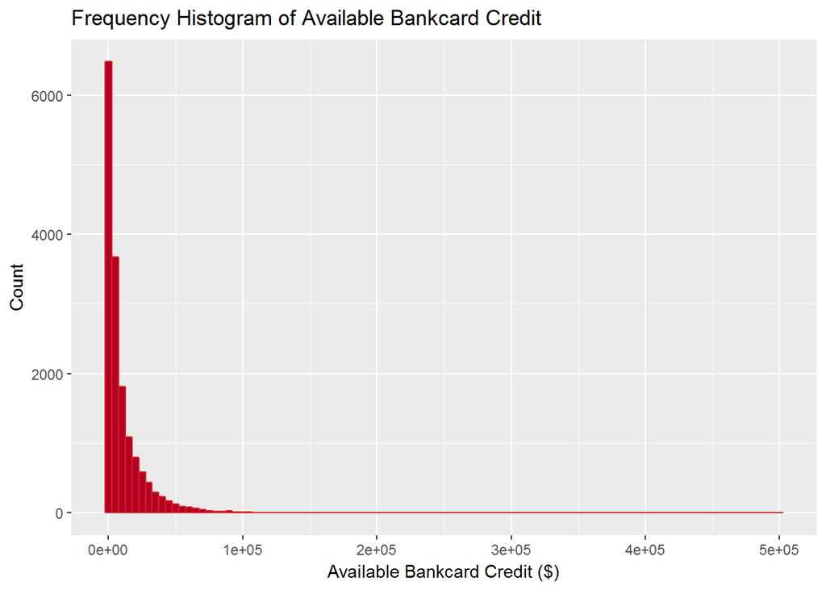

Trade Line is credit account records that are provided to credit reporting organization.

```r
summary(df$TotalTrades)
```

```
##    Min. 1st Qu.  Median    Mean 3rd Qu.    Max.
##    1.00   14.00   21.00   22.48   29.00  122.00
```

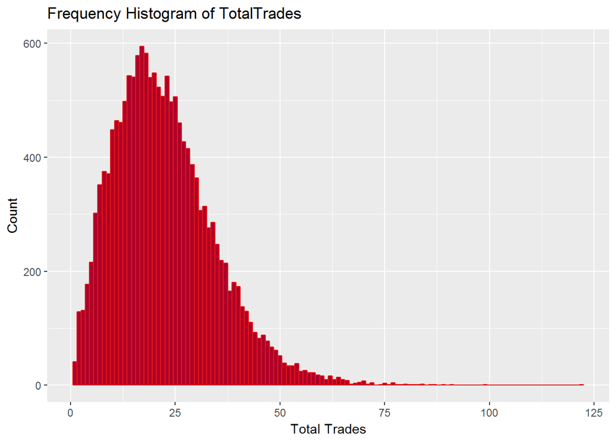

One of the most important features of the trade line is the payment status. The payment status will indicate that the payments are being made according to the terms of the credit agreement.

```r
summary(df$TradesNeverDelinquent..percentage.)
```

```
##    Min. 1st Qu.  Median    Mean 3rd Qu.    Max.
##   0.160   0.830   0.950   0.897   1.000   1.000
```

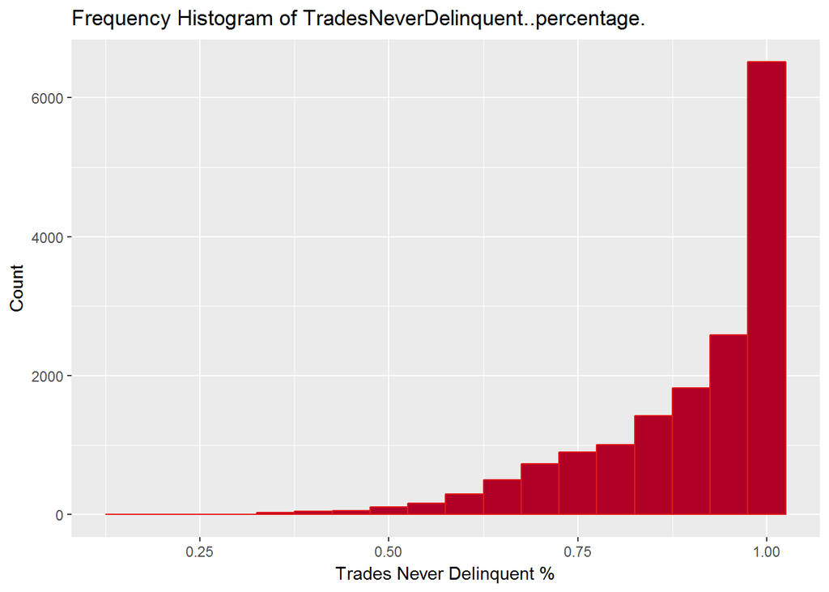

```r
summary(df$TradesOpenedLast6Months)
```

```
##    Min. 1st Qu.  Median    Mean 3rd Qu.    Max.
##  0.0000  0.0000  0.0000  0.7633  1.0000 20.0000
```

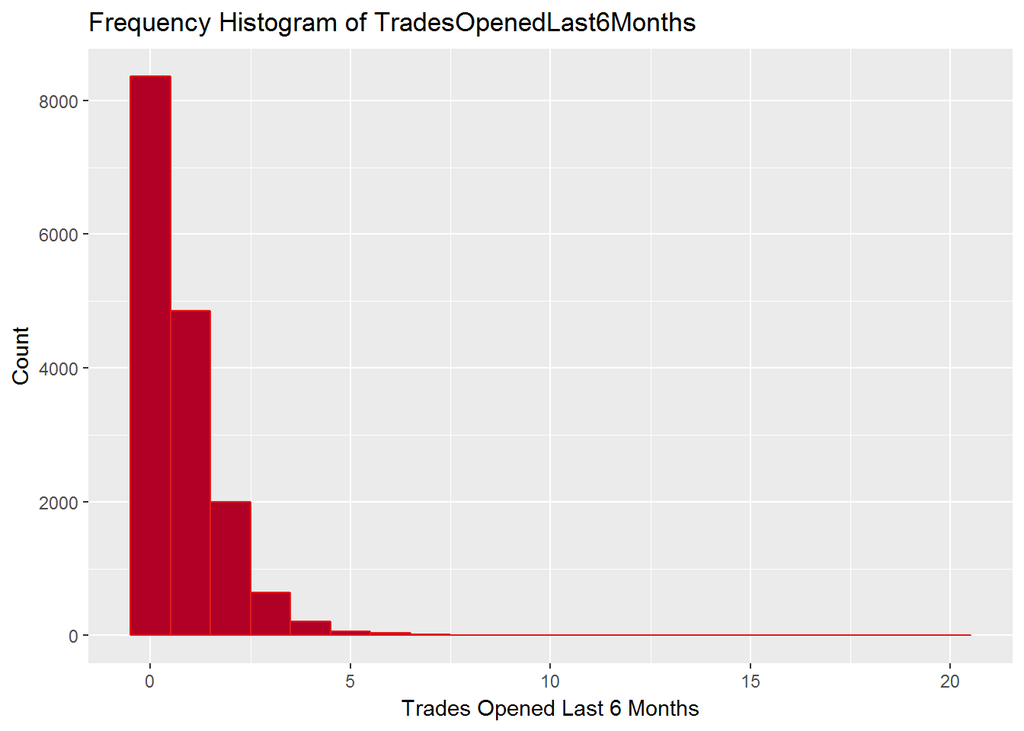

The ‘DebtToIncomeRatio’ variable, the sum of the borrower’s monthly debt payments divided by the borrower’s monthly income.

```r
summary(df$DebtToIncomeRatio)
```

```
##    Min. 1st Qu.  Median    Mean 3rd Qu.    Max.
##  0.0000  0.1300  0.1900  0.2453  0.2900 10.0100
```

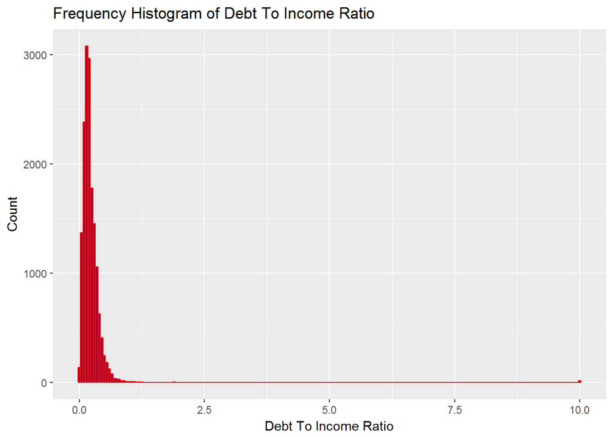

Given that in the dataset does not contain declined Loan. The plots give indications,if we can get a loan based on variable concern the credit history and indebtedness, although it would need to consider their combination to understand it.

# Univariate Analysis

### What is the structure of your dataset?

Prosper provides information about loan. The “Loan Data from Prosper” data set contains 113,937 loans with 81 variables on each loan. The Prosper Marketplace offers fixed rate, fully amortizing, unsecured consumer loans. On the basis of a series of considerations and evalutation, the data set of the analysis contains 16,189 loans: It is considered the period after SEC registration is considerd. More precisely, all loans that have ProsperRating..numeric.,ProsperRating..Alpha.,ProsperScore,CreditScoreRangeLower,CreditScoreRangeUpper. Furthermore, the borrower has no prior loans. The debtors with more loans create distortion of the data for the fact that create duplicate values for the same variable. Given that, we want investigate the characteristics of loans that go into default, we do not consider loans whose " LoanStatus" is current. Then, in Prosper Marketplace,currently, loan terms of three and five years are available. Therefore, loan terms of one years are excluded. Loans with missing values are not considered. This choice because after initial screening, few loans had missing values and only for the ‘DebtToIncomeRatio’ variable.

### What is/are the main feature(s) of interest in your dataset?

In the dataset, there are of variables that express synthetic judgment of credit risk of a prospective debtor,that is the ability to repay debt. This variables have an important function in a marketplace lending, reduce asymmetric information between borrowers and lenders.In the online lending market, trust is an important issue. And, Identifying riskiness of the borrower, thi variables allow investors to be aware of the risk that they are taking. This variable are: CreditGrade,ProsperRating..numeric., ProsperRating..Alpha.,ProsperScore,CreditScoreRangeLower,CreditScoreRangeUpper. Folowing SEC Registration Prosper created a model that determined “Prosper Ratings”. On the site of Prosper, it’s available Prospectus, the offering document included in the registration statement filed with the SEC. It allows of understand rating system of Prosper and a lot of information. The Prosper Rating, ‘ProsperRating..Alpha.’ variable , is a letter that indicates the expected level of risk associated with the loan. Each letter grade corresponds to an estimated average annualized loss rate range.  
We have custom Prosper Score, ‘ProsperScore’, and a credit score obtained from a credit reporting agency, ‘CreditScoreRangeLower’,‘CreditScoreRangeUpper’. The ‘Prosper Score’ predicts the probability of default, that is the probability of a Borrower Loan going “bad,” through custom risk model that using historical data as well as a data archive from a consumer credit bureau. The probability of bad ranges correspond Prosper Scores.

### What other features in the dataset do you think will help support your investigation into your feature(s) of interest?

The ‘Prosper Score’ is important to determinate “Prosper Ratings”. In the dataset, there are variables to determine the probability of default.In particular, we consider the following variables: CurrentCreditLines,OpenCreditLines,TotalCreditLinespast7years,OpenRevolvingAccounts, OpenRevolvingMonthlyPayment,RevolvingCreditBalance,BankcardUtilization,AvailableBankcardCredit, InquiriesLast6Months,TotalInquiries,CurrentDelinquencies,AmountDelinquent,DelinquenciesLast7Years, PublicRecordsLast10Years,PublicRecordsLast12Months,TotalTrades,TradesNeverDelinquent..percentage., TradesOpenedLast6Months and DebtToIncomeRatio.

### Did you create any new variables from existing variables in the dataset?

In the dataset, we have Lower Range and Upper Range for credit score obtained from a credit reporting agency. New variable FICO corresponds middle point of Credit Score range.

### Of the features you investigated, were there any unusual distributions? Did you perform any operations on the data to tidy, adjust, or change the form of the data? If so, why did you do this?

The values of ‘LoanStatus’ variable is one of the following: ‘Completed’, ‘Final Payment in Progress’, ‘Charge-Off’, ‘Defaulted’, ‘Past Due (1-15 days)’, ‘Past Due (16-30 days)’, ‘Past Due (31-60 days)’, ‘Past Due (61-90 days)’, ‘Past Due (91-120 days)’, ‘Past Due (>120 days)’. New values are: ‘Completed’, ‘Chargedoff’, ‘Past Due (<60 days)’, ‘Past Due (>60 days)’, ‘Defaulted’.  
We consider the loans in ‘Final Payment in Progress’ status as ‘Completed’ status given that loans that is in the process of being completed. Most loans that are in this status move to the Completed status within the next period. Given the definition of “bad” loan,in the Prosper Prospectus,is the probability of going 60+ days past due within the first twelve months from the date of loan origination, we consider two status ‘Past Due (<60 days)’ status , ‘Past Due (>60 days)’ for past due status. Understand if the status of a loan it is closer to “defaulted” status, it is important when we will create a binary variable: default or not.

# Bivariate Plots Section

For every variable, we determine number of default and observations for particular percentile and then derive the corresponding empirical default frequency, edf. We create new Variable a binary variable,Badloan, which can take only two possible values: 0, if status is “Completed” or “‘Past Due (<60 days)’, and 1, if status is ‘Past Due (>60 days)’, ‘Charge-Off’, ‘Defaulted’.

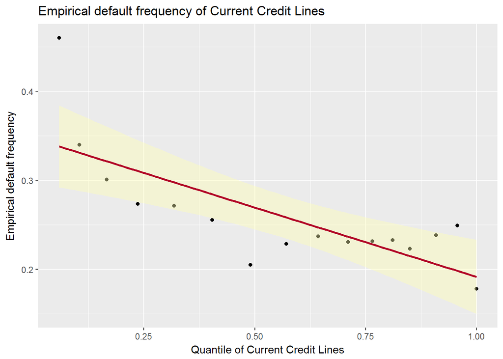

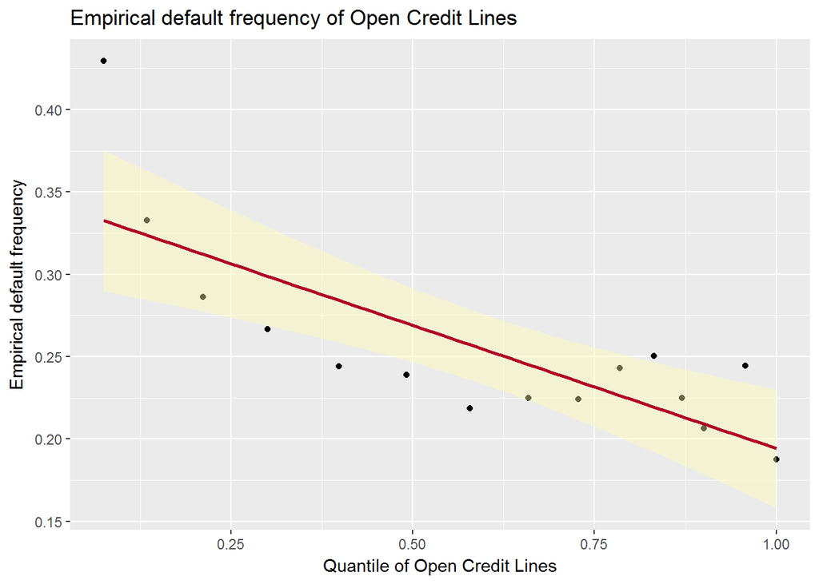

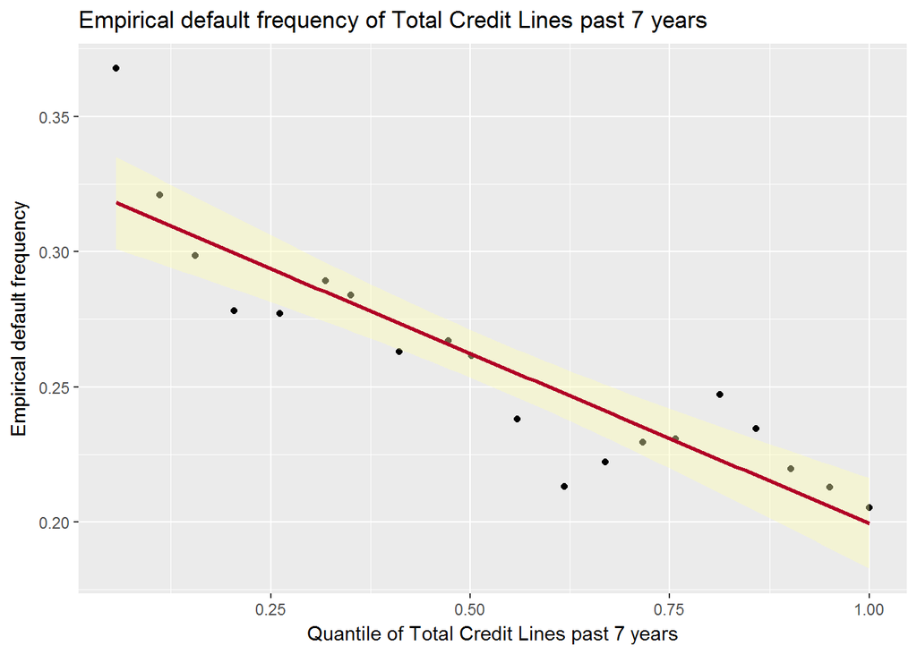

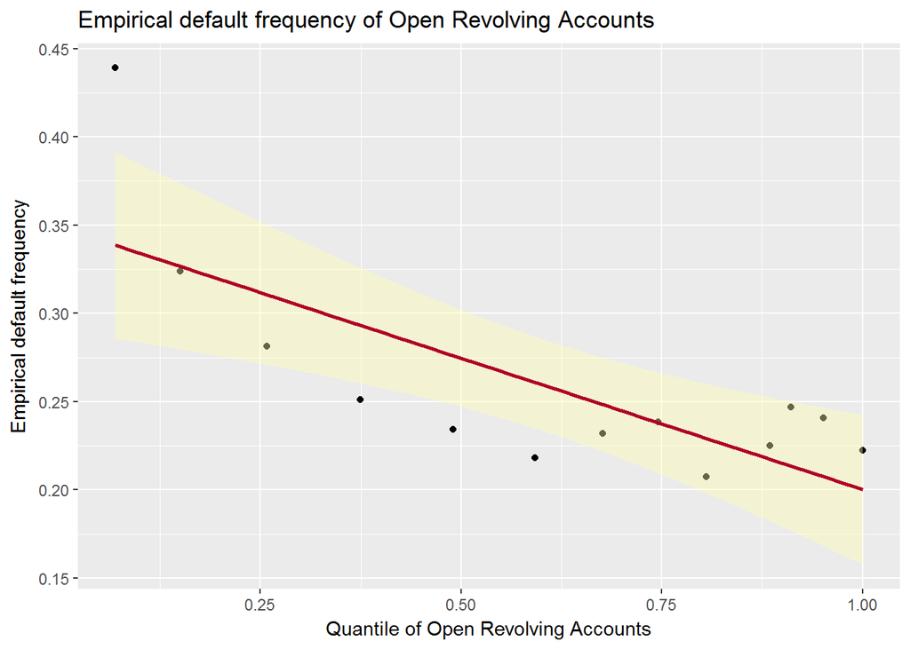